# Practical Machine Learning Course Project

## Plots

As first glance, we will take a look on the distribution of the variable classe

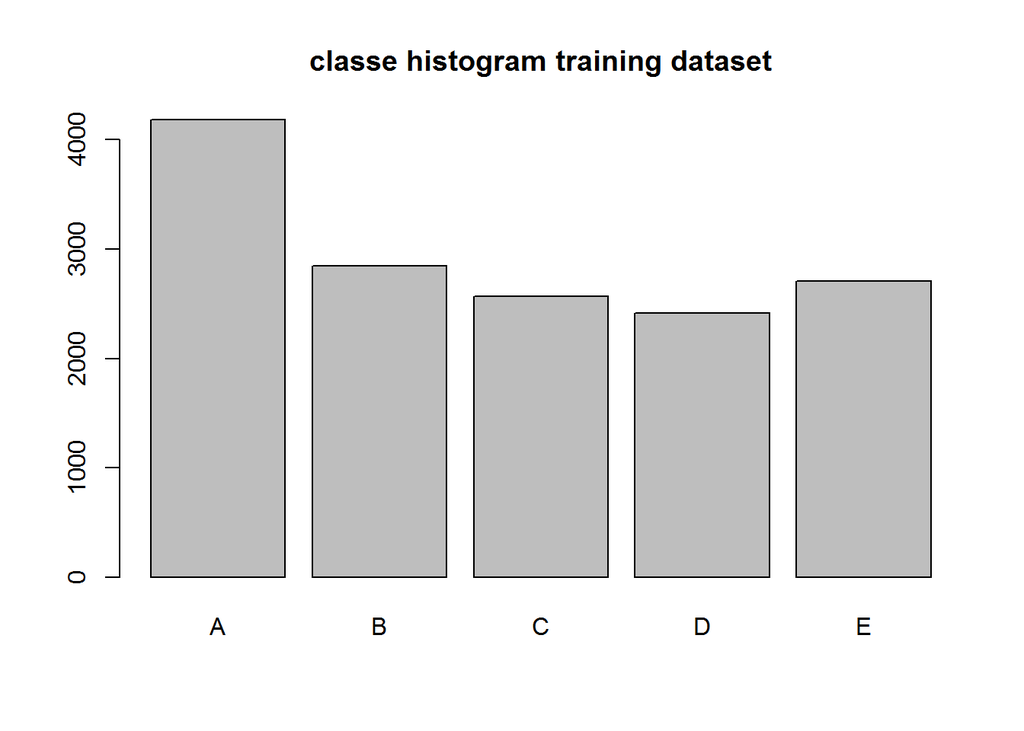

We have plotted all the remaining variables one versus the others (using featureplot). This can give us a hint on variables which can be good predictors. Here are few plots of variables that seem to be good predictors.

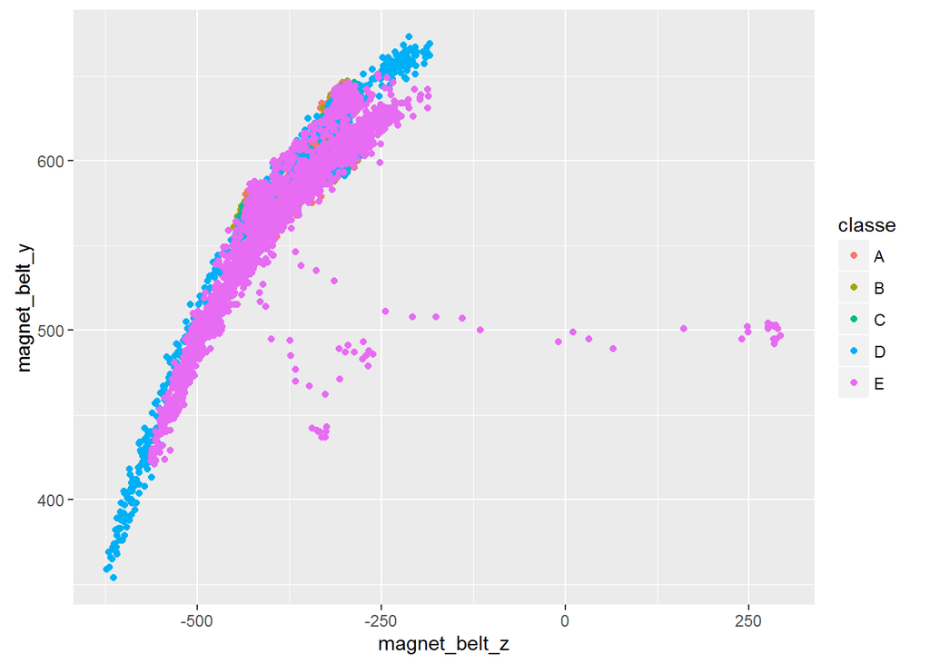

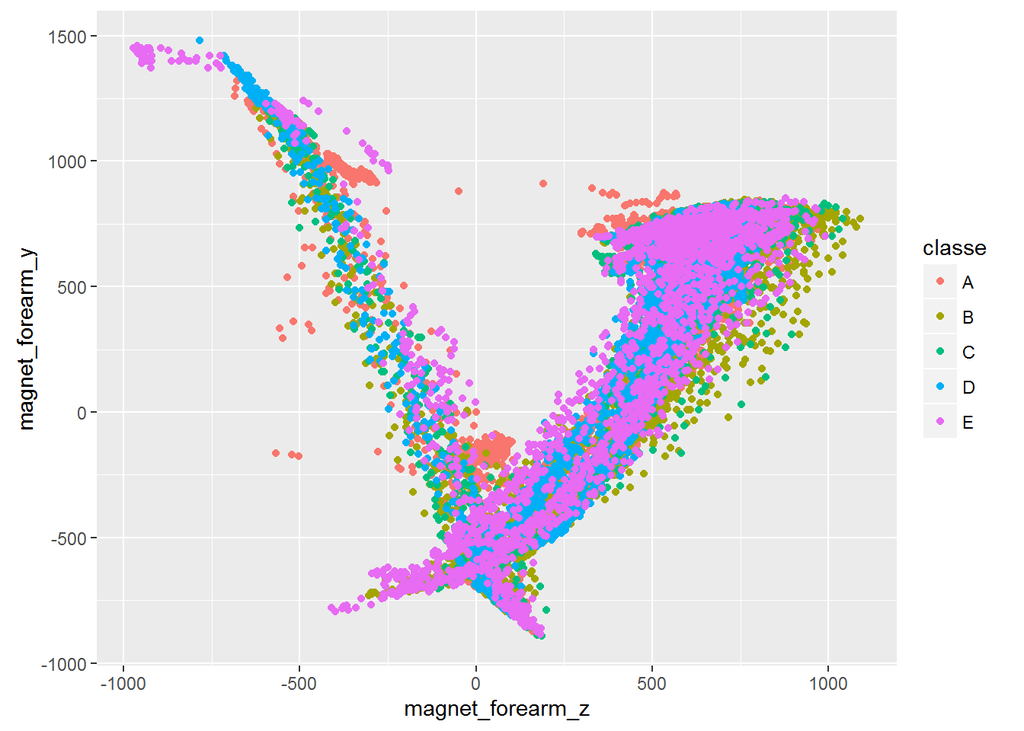

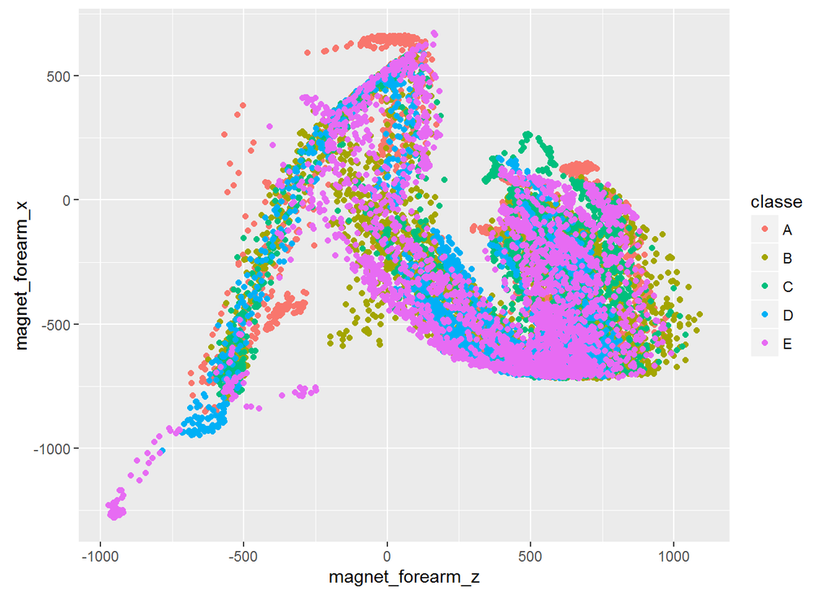

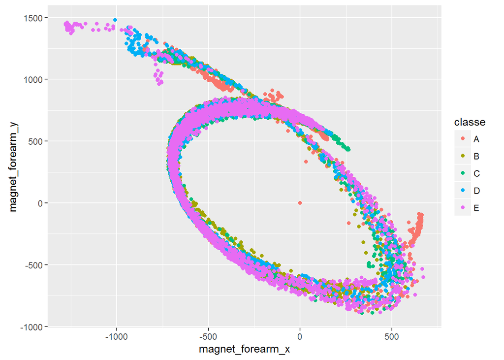

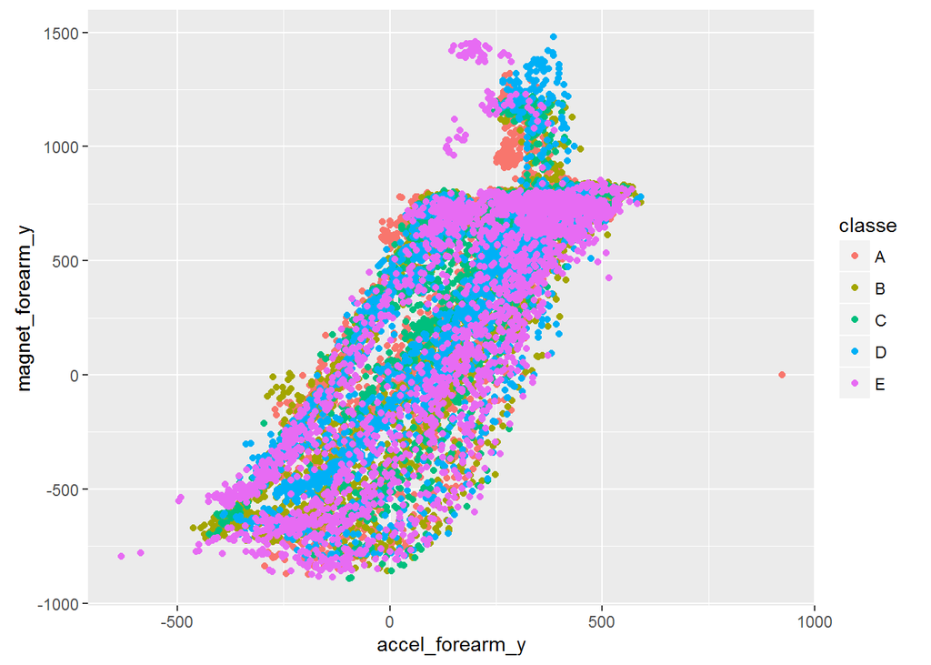

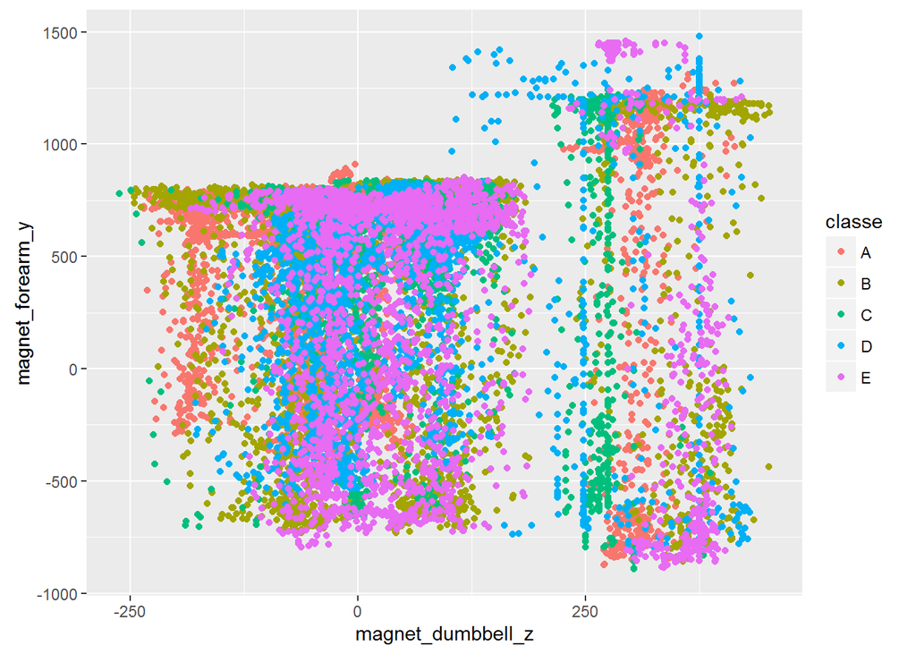

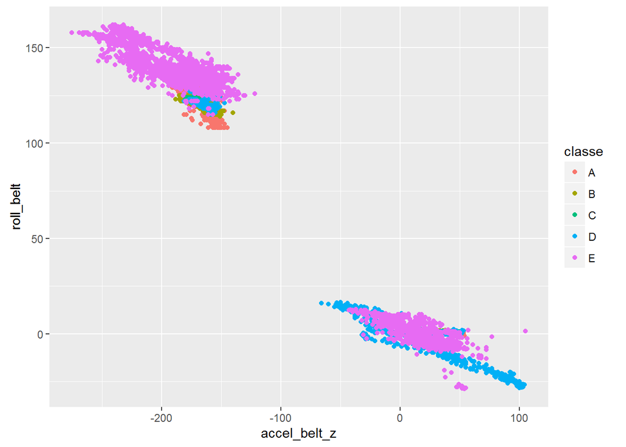

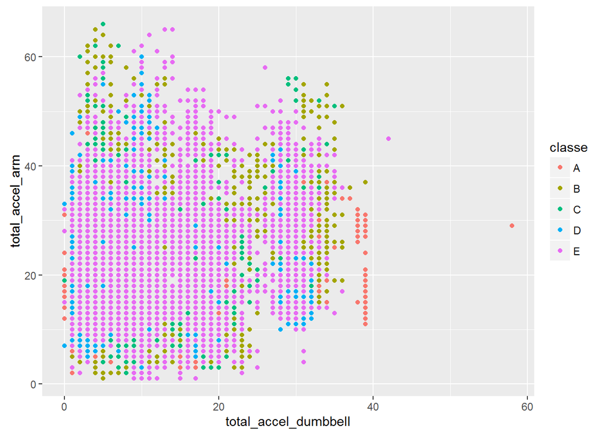

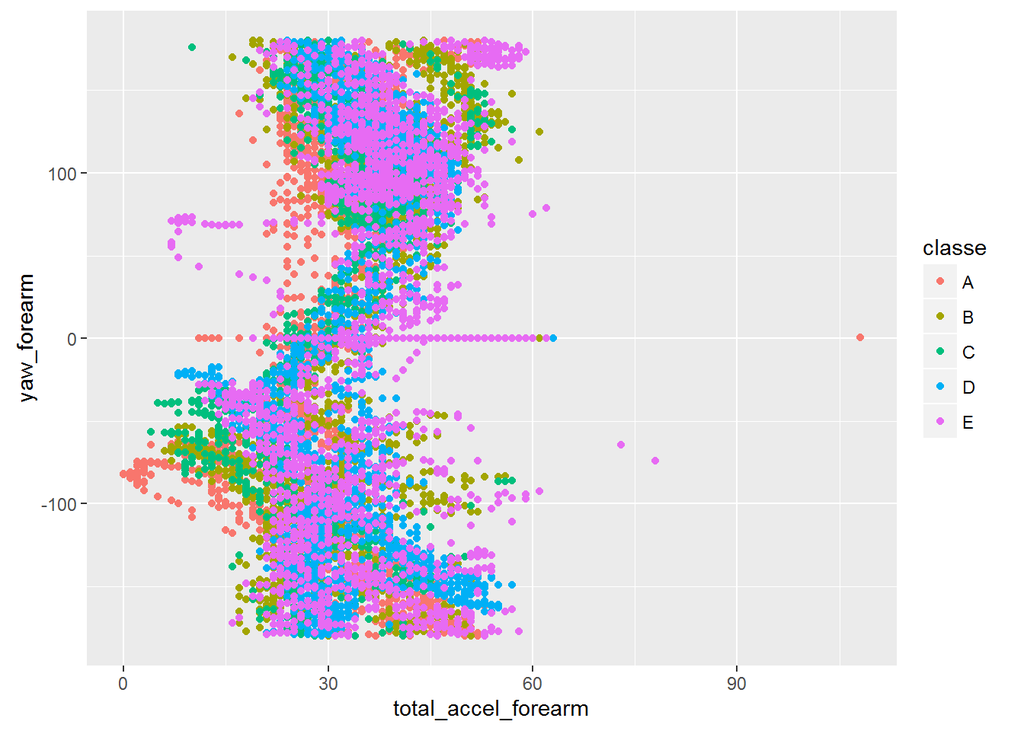

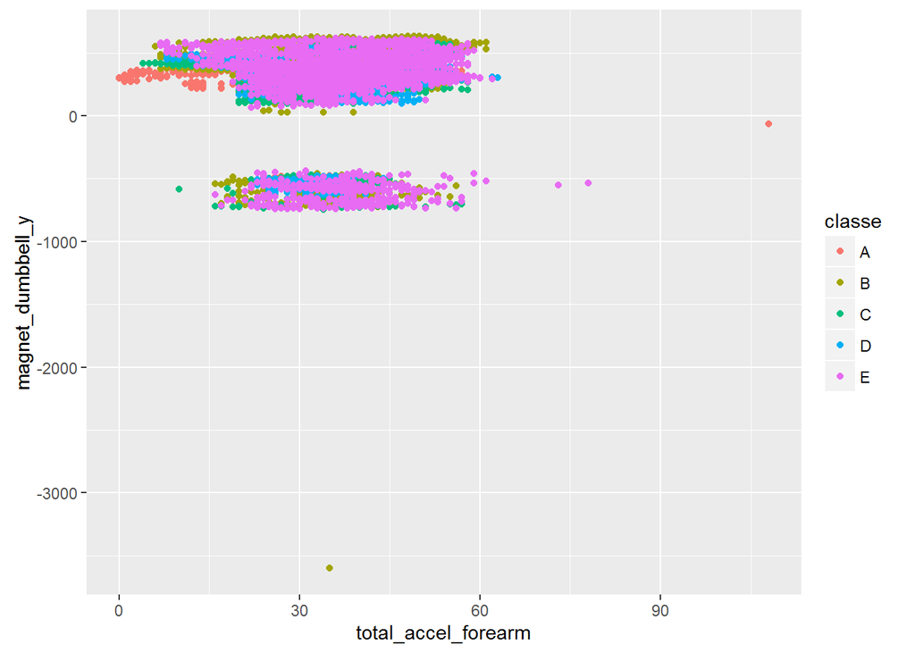

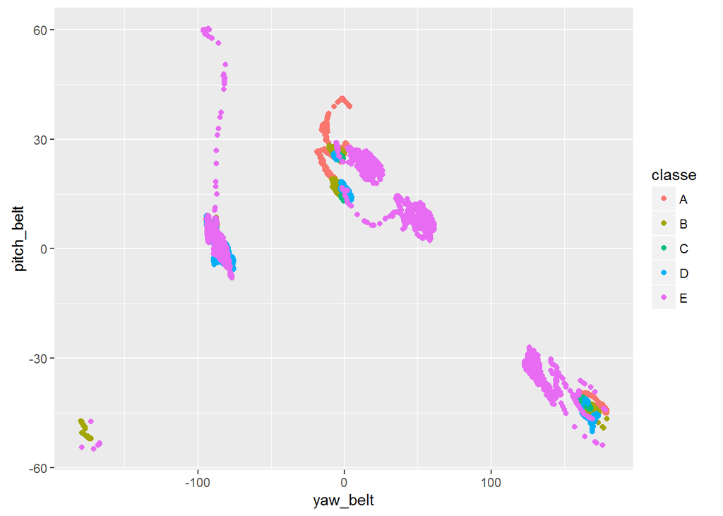

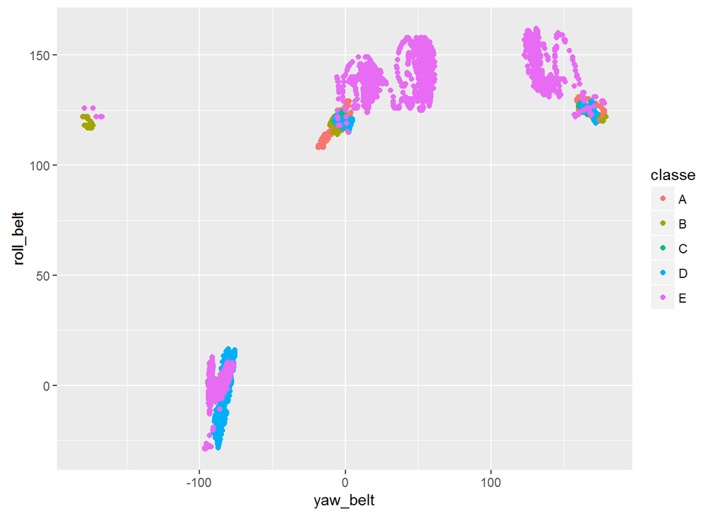

[7 more figures not shown]

## Comparing models

We will use the Kappa criteria to measure errors because of the classification type. We have compared 6 classification algorithms: knn, gbm, LogitBoost, J48, rpart and C5.0. Off records, the random forest algorithm give very low accuracy and kappa values and consumes a lot of computational energy. For this purpose we have excluded it.

```
##       Method                  MethodLabel TrainAccuracy TrainKappa
## 1        knn          k-Nearest Neighbors     0.9504710  0.9373404
## 2        gbm Stochastic Gradient Boosting     0.8208989  0.7731902
## 3 LogitBoost  Boosted Logistic Regression     0.6371266  0.5285436
## 4        J48              C4.5-like Trees     0.8577950  0.8201209
## 5      rpart                         CART     0.3872091  0.1950055
## 6       C5.0                         C5.0     0.9607992  0.9504090
##   TestAccuracy TestKappa Duration(minutes)
## 1    0.9569739 0.9455450                35
## 2    0.8254486 0.7787757                 6
## 3    0.6196853 0.4961978                47
## 4    0.8656199 0.8298102                 5
## 5    0.3627651 0.1420483                14
## 6    0.9616639 0.9514834                47
```

# Stacking models

```
##    Method                  MethodLabel TrainAccuracy TrainKappa
## 1     gbm Stochastic Gradient Boosting     0.8208989  0.7731902
## 2     knn          k-Nearest Neighbors     0.9504710  0.9373404
## 3    C5.0                         C5.0     0.9607992  0.9504090
## 4 bagging              majority voting            NA         NA
##   TestAccuracy TestKappa Duration(minutes)
## 1    0.8254486 0.7787757                 6
## 2    0.9569739 0.9455450                46
## 3    0.9616639 0.9514834                46
## 4    0.9718597 0.9643934                 1
```

## Conclusion

By stacking 3 models and majority voting, we can reach prediction accuracy that is greater than 95%.